# R Notebook

# WTF is ‘List’ in R?

- 앞으로 R에서 활용되는 객체로서의 list와 vector는 문장의 앞에 오지 않더라도 대문자로 쓰도록 하겠다.

R에서 제일 이해하기 힘든 객체가 list다. 어차피 데이터 분석 할 때는 Data.frame를 쓰니 List는 몰라도 되는 거 아님?, 이라고 반문할지 모르겠다. 하지만 R에서 많은 객체들은 List의 형태로 남는다. 이 친구에 접근하는 법을 모르면 많은 분석 결과에 접근하기 힘들게 되는 경우가 많다. 아울러, json 포맷을 파싱하게 되면 List로 돌아오는 경우가 많다. 따라서 데이터 분석을 하게 되더라도 List는 꼭 마주치게 된다. List를 살펴보기에 앞서 Vector라는 개체 이해해보자.

## Categorizing vectors

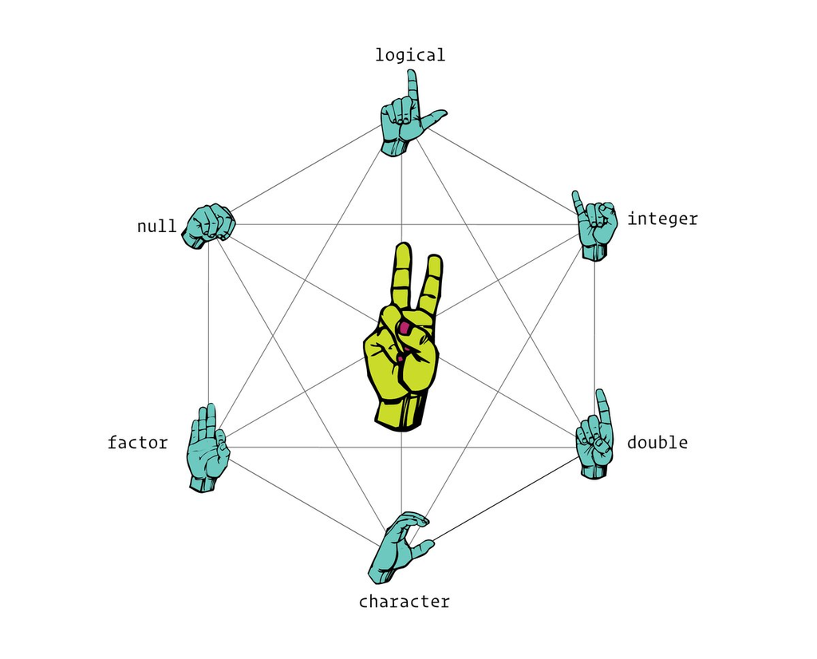

다시 정리해보자. 단일한 원소로 구성된 객체의 종류는 Null을 제외하고는 Logical, Integer, Double, Character로 구분된다. 그리고 Integer는 factor를, Double에는 POSIXct, Dat를 포괄한다. 이런 단일 원소를 Atomic이라고 부르고 같은 유형의 Atom로 구성된 vector가 Vector다. List에 대해서는 잠시 후에 설명하자.

[figure not shown]

위의 그림에서도 알 수 있지만, List는 요소들이 모여 있다는 점에서는 Vector다. 그런데 같은 요소들이 모두 같은 유형인 atomic vector와 구별된다. 구별되는 대목은 아래와 같다.

1. 요소들의 유형이 서로 달라도 된다.
2. 여기서 유형이 다르다 함은 단시 logical인지 등 만을 지칭하지 않는다. List는 요소로 Vector를 지닐 수도 있고 List를 지닐 수도 있다. 아울러 요소들 사이의 길이가 동일하지 않아도 된다.
3. list에는 개별적으로 이름이 부여될 수도 있다.

## How to index List

Vector를 인덱싱하는 것은 비교적 쉽고 자명하다.

```r
(v_log <- c(TRUE, FALSE, FALSE, TRUE))
```

```
[1]  TRUE FALSE FALSE  TRUE
```

```r
(v_int <- 1:4)
```

```
[1] 1 2 3 4
```

```r
(v_doub <- 1:4 * 1.2)
```

```
[1] 1.2 2.4 3.6 4.8
```

```r
(v_char <- letters[1:4])
```

```
[1] "a" "b" "c" "d"
```

```r
#
v_char[c(FALSE, FALSE, TRUE, TRUE)]
```

```
[1] "c" "d"
```

```r
v_char[v_log]
```

```
[1] "a" "d"
```

```r
v_doub[2:3]
```

```
[1] 2.4 3.6
```

```r
v_char[-4]
```

```
[1] "a" "b" "c"
```

R에서 `-`는 제외될 원소를 의미한다.

그렇다면 List는 어떻게 인덱싱될까? 우선 구별해야 하는 것은 List의 구조 자체를 유지하면서 인덱싱을 할지, 아니면 구조는 버릴지에 대한 것이다. `[`, `[[`이 이렇게 구별된다. 위캠이 제시한 재미있는 설명을 소개하겠다.

[figure not shown]

병이 List 구조이고 안에 후추 패킷이 요소다. 이때 `x[1]`로 인덱싱을 하면 아래와 같은 형태로 인덱싱이 된다.

[figure not shown]

만일 안에 있는 패킷 하나면 꺼내고 싶다면, `x[[1]]`로 인덱싱을 하면 된다.

[figure not shown]

만일 안에 후추를 얻고 싶다면, `x[[1]][[1]]`

[figure not shown]

재미있는 그림이다! 이름으로 인덱싱할 때는 어떻게 될까?

```r
tmp_list <- list( x = list(xx = c(1,3,4), xy = 10), y = 40)
```

원하는 것은 tmp_list에서 `xx`, 즉 `c(1,3,4)`를 추출하는 것이다. 논리적으로 보면 `tmp_list[[1]][[1]]` 이렇게 할 수 있겠다. 이와 같은 효력을 발휘하는 명령어는 `tmp_list[[c(1,1)]]` 혹은 `tmp_list[[c('x', 'xx')]]` 이렇게 c로 묶어줄 경우에는 깊이를 타고 내려가 인덱싱이 가능하다. 아래의 사례들도 참고하자.

```r
x1 <- list(c(1, 2), c(3, 4))
x2 <- list(list(1, 2), list(3, 4))
x3 <- list(1, list(2, list(3)))
```

[figure not shown]

## 참고 자료

- http://r4ds.had.co.nz/lists.html
- https://jennybc.github.io/purrr-tutorial/